# Final project - Data Processes UPM 2019/2020

Eduard Aymerich, Fernando Alonso, Rafael Timermans, Bowen Huang and Jaime Acosta

12/16/2019

# Movies analysis

## Abstract

This analysis was conducted to illustrate some important and curious facts about something that has been fascinating people for more than 100 years. Since Lumiere brothers created the first short film this industry has evolved a lot. Nowadays, with the internet, we have been surrounded by movies every day so we thought it would be interesting to go a little bit further about the data that it has behind. Can producers predict what people will prefer in the future in the cinema industry? Have most popular films any pattern to be most preferred? In this study, we will answer some questions like those and go deep in movies data, analysing and predicting some films attributes.

## Introduction and Related work

Cinema is the most complex and powerful art form in the present world. It can help us to better understand our own lives, the lives of those around us and even how our society and culture operate. They can shed light on political and spiritual matters too, and can provide catharsis and perspective and may open our eyes to new ways of thinking, feeling and pursuing our lives. This is why, in our way, we want to pay tribute with this movies analysis. Why we love some movies and hate others? We will conduct a study to try to understand better how movies and people are really connected.

We have found some inspirational data science projects related to this domain:

- [Data science analysis of movies released in the cinema between 2000 and 2017](https://medium.com/datadriveninvestor/data-science-analysis-of-movies-released-in-the-cinema-between-2000-and-2017-b2d9e515d032): Consists in a general analysis of the data available on the IMDb website for movies released in the cinema between 2000 and 2017.
- [The most influential factor of imdb movie rating part in data scraping](https://towardsdatascience.com/the-most-influential-factor-of-imdb-movie-rating-part-i-data-scraping-61dc0c4dd518): Use data-scraping technique to extract data from a IMDb movie list, create a Dataset and figures out what are the primary factors that influence a movie’s success.
- [What makes a successful film predicting a films revenue and user rating with machine learning?](https://towardsdatascience.com/what-makes-a-successful-film-predicting-a-films-revenue-and-user-rating-with-machine-learning-e2d1b42365e7): It stroves to find out whether, knowing only things you could know before a film was released, what the rating and revenue of the film would be. It uses machine learning in a model on a randomized 90% of the movies, and then tested it on the remaining 10%.
- [Analyzing Movie Scores on IMDb and Rotten Tomatoes](http://rstudio-pubs-static.s3.amazonaws.com/336722_2193716117584b63a2a6ebb837217d85.html): This project aims to obtain insights regarding the interpretation and comparison among these different scoring systems through data analysis and visualization. One focus in this project would be to visualize the distributions of scores and see how they vary across the years and across different genres.
- [Movie Review Analysis: Emotion Analysis of IMDb Movie Reviews](https://www.researchgate.net/publication/305222147_Movie_Review_Analysis_Emotion_Analysis_of_IMDb_Movie_Reviews): Currently, moviegoers base their decisions as to which movie to watch by looking at the ratings of movies as well as reading some of the reviews at IMDb or Amazon. This paper argues that there is a better way: reviewers movie scores and reviews can be analyzed with respect to their emotion content, aggregated and projected onto a movie, resulting in an emotion map for a movie.

## Exploratory Data Analysis

In our analysis we will use the TMDB Movie Metadata dataset collected by Kaggle. The data was extracted from [The Movie Database](https://www.themoviedb.org) API to get almost 5000 films on 2017.

### TMDB Movie Metadata

This dataset contains 4803 rows with a total of 20 columns.

| *Name* | *Data type* | *Description* |
| --- | --- | --- |
| Budget | Integer | Movie budget in dollars |
| Genres | String | A comma-separated list of genres used to classify the film |
| Homepage | Url | Official website of the film |
| Id | Integer | Identification number of the film created by TMBD |
| Keywords | String | A comma-separated list of keywords used to classify the film |
| Original_language | String | Original language of the film |
| Original_title | String | Original title of the film |
| Overview | String | Short description of the film |
| Popularity | Decimal | Popularity in the TMBD website |
| Production_companies | String | A comma-separated list of production companies in the film |
| Production_countries | String | A comma-separated list of production countries in the film |
| Release_date | Date | Release date in YYYY-MM-DD format |
| Revenue | Integer | Movie revenue in dollars |
| Runtime | Integer | The duration of the film in minutes |
| Spoken_languages | String | A comma-separated list of languages spoken in the original film |
| Status | String | Indicates if movie released. Values are “Released” or “Rumored” |
| Tagline | String | Short text to clarify or make you excited about the film |
| Title | String | The title of the film |
| Vote_average | Decimal | Average of users rating for the movie 0-10 |
| Vote_count | Integer | Number of votes |

```r
summary(tmdb_movies)
```

The most relevant features for this study are Budget, Genres, Revenue, and vote_average. We will use more than these ones but are lees important.

We will clean a bit the data, so we will only use movies with all the fileds completed (no NA data), we wont consider either the movies with budget or revenue that equals 0, as we suppose that this is an error. In addition, each film has multiple genres, but we will only consider the first genre of each movie.

#### Revenue and budget

First we will print a graph relating the revenue and budget, and with color information about the vote average, to see if we can se a relationship.

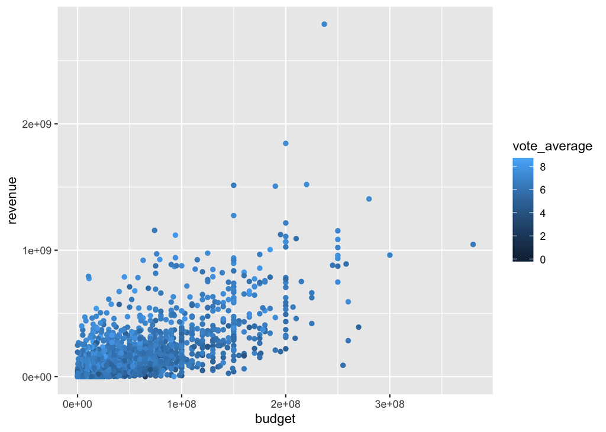

We can see that it may exist a relationship between the revenue of a film and the budget invested, but it doesn´t seem like any of those feature is related to vote average in the graph, so let´s print in a separate graph.

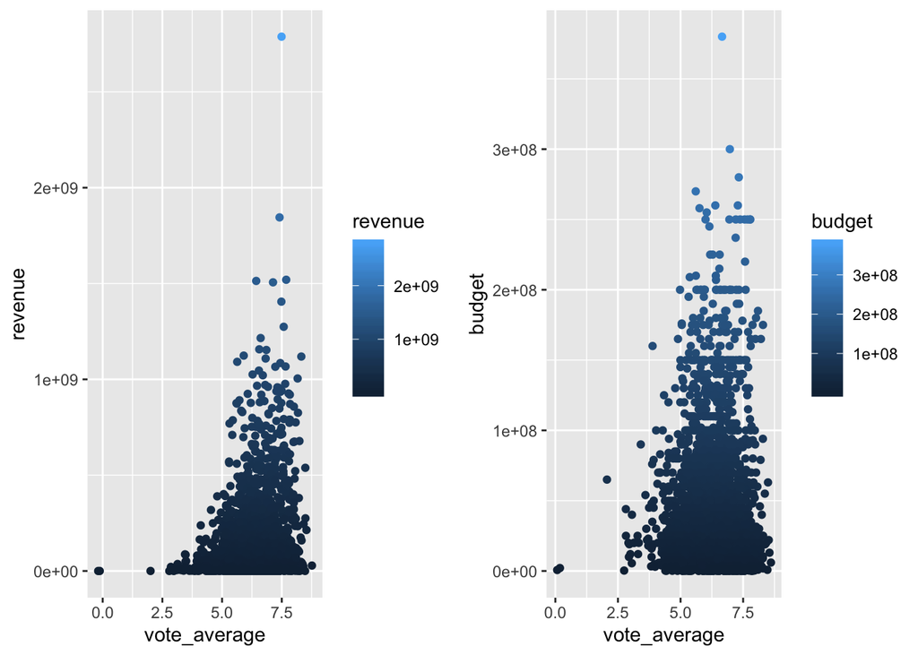

We can see it clearer now, and we can appreciate that it is possible that there is a relationship between the vote average and the revenue, but doesn´t seem like that with the budget.

We are going to compare these features with the genre of the film, so we can see if action movies earn more mony than others genres movies.

#### Genre

Lets see if there is a relation between genre and revenue, so we can compare if a genre is better to make money than other.

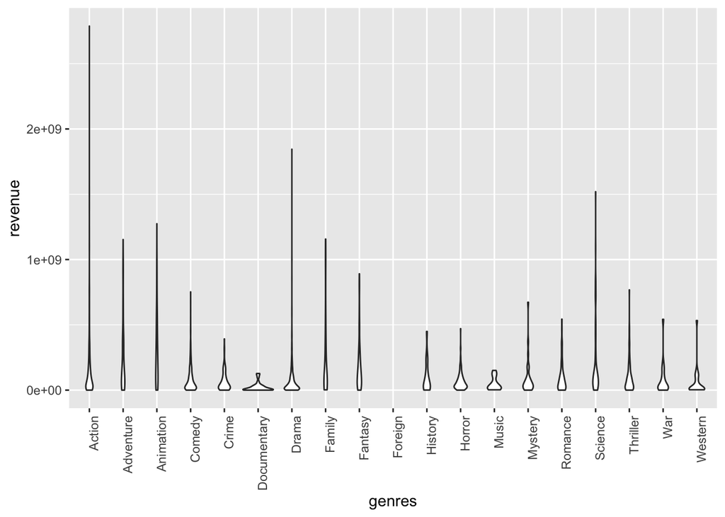

```r
gen_vot <- ggplot(movies2, aes(x=genres, y=revenue),las=2) +
  geom_violin()
gen_vot + theme(axis.text.x = element_text(angle = 90, hjust = 1))
```

We are going to compare with the vote average too, so we will quit all the movies with few votes.

```r
summary(movies2$vote_count)
```

[output not shown]

There is a big difference between the most voted and the least, so we are not going to use the ones in the first quartile.

```r
# there are a lot of films who doesnt have many votes (half of movies have less than 471 votes), we have to use only fimls which have more than 178 votes
# (1st quartile)
movies_reduced_votes <- movies2 %>% # data frame to start with
  filter(vote_count>178)  %>%
  filter(genres=="Action" | genres=="Adventure" | genres=="Animation" | genres=="Comedy" | genres=="Drama" | genres=="Family" | genres=="Fantasy" | genres=="Romance" | genres=="Thriller" | genres=="Science")
```

Once we have a cleaner dataset, we want to compare the genre with revenue and score. In order to do that, we convert the vote average in facotr, so we round the number (it is a 1 to 10, scale).

```r
# making a facet with vote integers
movies_reduced_votes$vote_average = sapply(movies_reduced_votes$vote_average, function(x) floor(x/1))
movies_reduced_votes$vote_average <- as.factor(movies_reduced_votes$vote_average)
```

We make a plot now comparing these three variables, to see if there is a pattern.

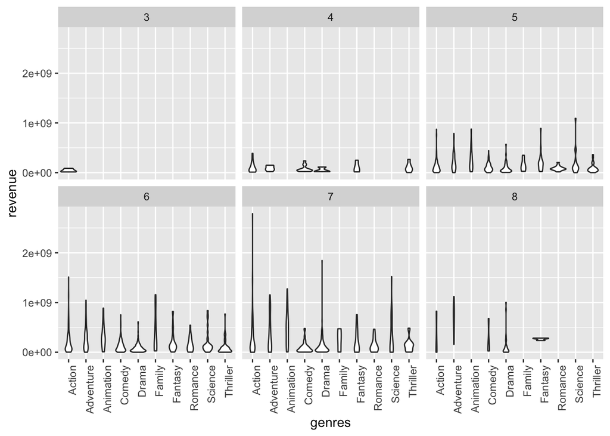

```r
# we only lost like 400 movies, they were not common films then, good
gen_vot <- ggplot(movies_reduced_votes, aes(x=genres, y=revenue)) +
  geom_violin()

gen_vot <- gen_vot+facet_wrap(~vote_average)
gen_vot + theme(axis.text.x = element_text(angle = 90, hjust = 1))
```

We see than the genres revenue are similar, but when the score rounds the seven, action films earn much more money than the rest. To see if there is a different pattern with the action movies, we are going to do the same graphics than before but only with action movies.

#### Action movies

We need to clean the data first:

```r
# lets see revenue vs budget in action films compared to vote score, only for action movies
action_movies <- movies_reduced_votes %>%
  filter(genres == "Action")
```

And lastly we print the same graphs than before

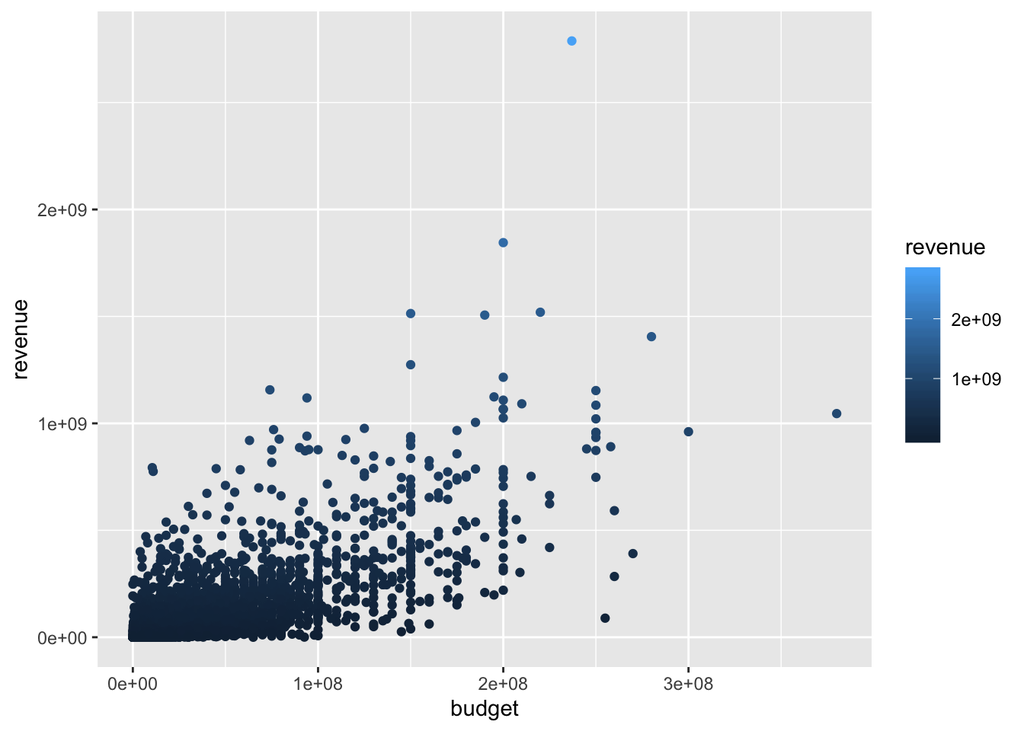

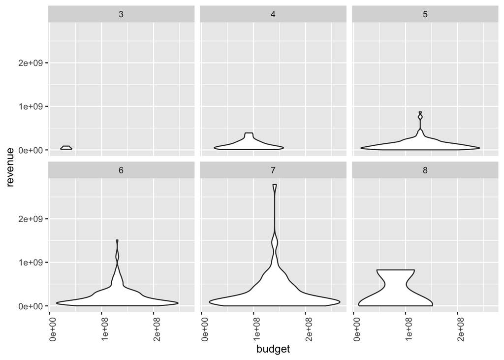

Movies than have an 8 as a vote_average don’t earn a lot or few money. We can also see that the ones that earn a lot of money they have an average budget.

The first graph is the same that the one considering all genres, so it is no usefull for the study. However, we can see that in action films it is possible that the revenue is indeed related with the vote_average, so as the vote average rise, there are more films which have more revenue. The exception is the movies with more than an 8. These movies doesn´t have a big revenue, but they doen´t invest too much money in the budget neither, so they are likely profitable.

#### Money vs Time

We are going to plot some graphs tto see if there is a tendency to invest or earn more money with time. We are going to consider all the movies.

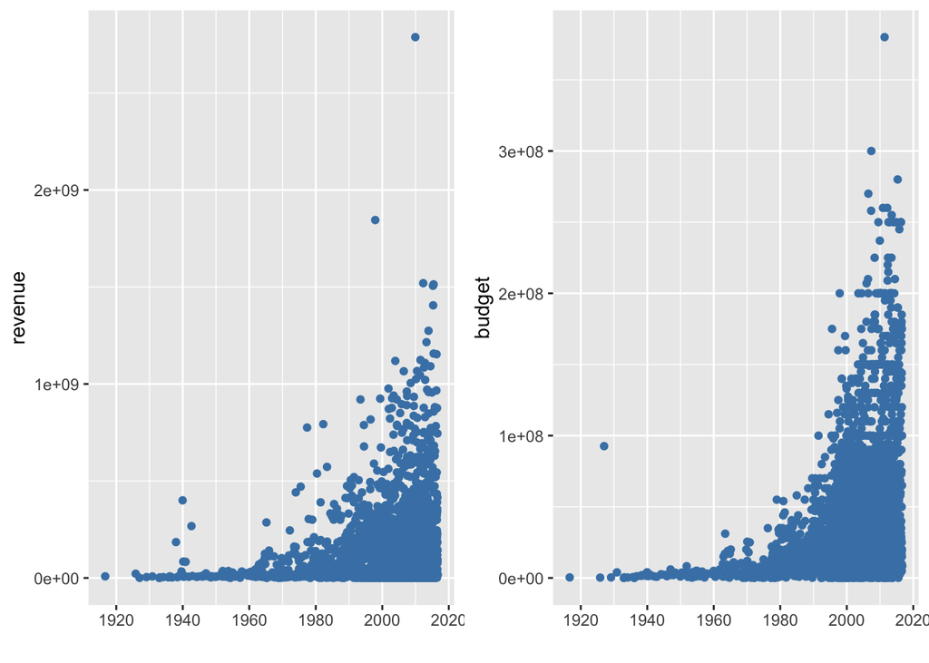

[figure not shown]

## Questions of interest

- What attributes makes the film better (with better we refer to the money earned, the popularity, the ratings)?
- Does the duration of film influence the average of users rating?
- Are some film genres more popular than others? Have it changed during years?
- Have old films better critic scores than recent ones?
- Can a film earn a more than 1 billion dollars if the genre is not one of the top3 popular gender in that year?
- The release year influences in the popularity and revenue of a movie?

## Methods

### Strength of relationships

First we will clean the data

#### Question 1) First we will see which attribute makes the film earn more money.

Step 1.1) Select rows that we will use. In this case the earn money (*revenue*) are related to the variables *budget*, *genres*, *production companies*, *release date* and *spoken languages*.

```r
movies_related_revenue <- tmdb_movies_clean %>% select(revenue, budget, genres, popularity, production_companies, release_date, vote_average, spoken_languages)
```

Step 1.2) Compare the variable *revenue* with other variables.

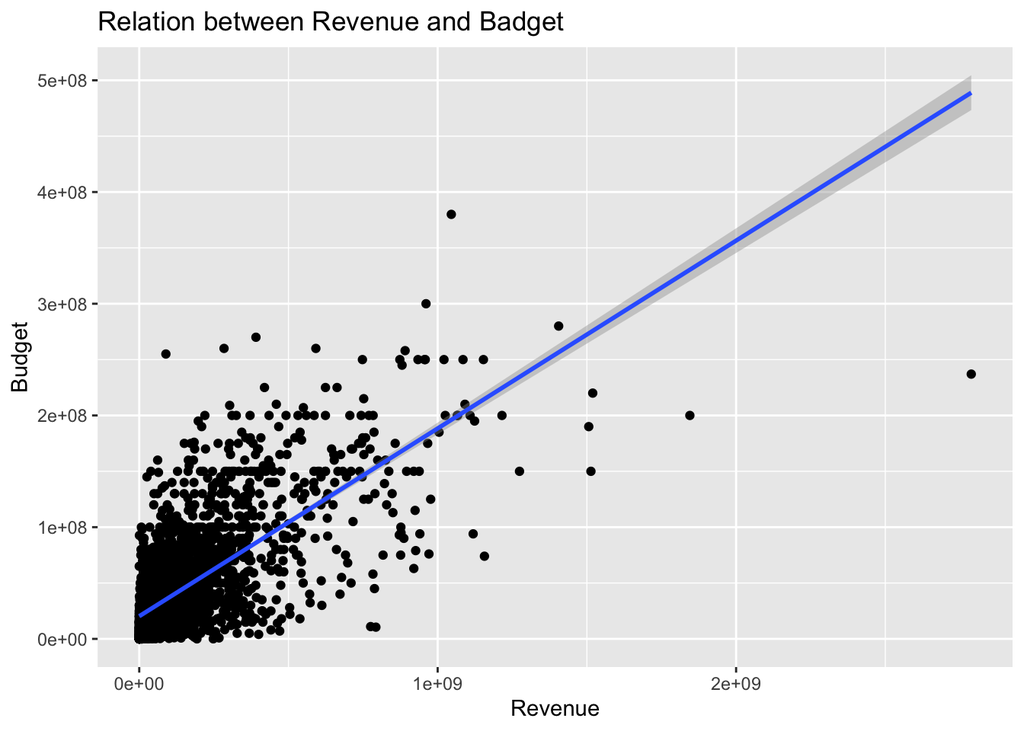

```r
movies_r <- movies_related_revenue %>% select(revenue, budget)
cor(movies_r$revenue, movies_r$budget)

ggplot(movies_related_revenue, aes(x=revenue, y=budget))+
  geom_point()+
  geom_smooth(method=lm)+
  labs(x="Revenue", y="Budget", title="Relation between Revenue and Badget")
```

```r
regression_model = lm(formula = revenue ~ budget + genres + popularity + production_companies + release_date + spoken_languages, data=movies_related_revenue)

summary(regression_model)
```

#### Question 2) Secondly we will see which attribute makes the film more popular in the TMBD website.

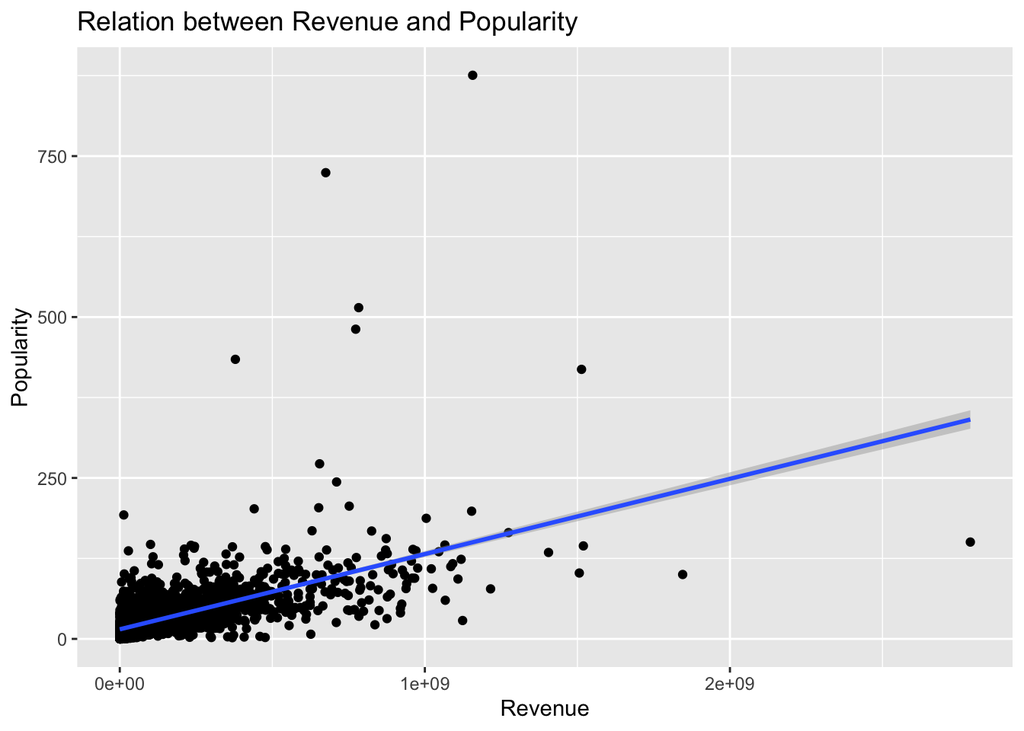

```r
movies_r <- movies_related_revenue %>% select(revenue, popularity)
cor(movies_r$revenue, movies_r$popularity)

ggplot(movies_related_revenue, aes(x=revenue, y=popularity))+
  geom_point()+
  geom_smooth(method=lm)+
  labs(x="Revenue", y="Popularity", title="Relation between Revenue and Popularity")
```

```r
regression_model = lm(formula = revenue ~ popularity + budget + genres + production_companies + release_date + spoken_languages, data=movies_related_revenue)

summary(regression_model)
```

#### Question 3) Now we will see which attribute makes the film better voted by users.

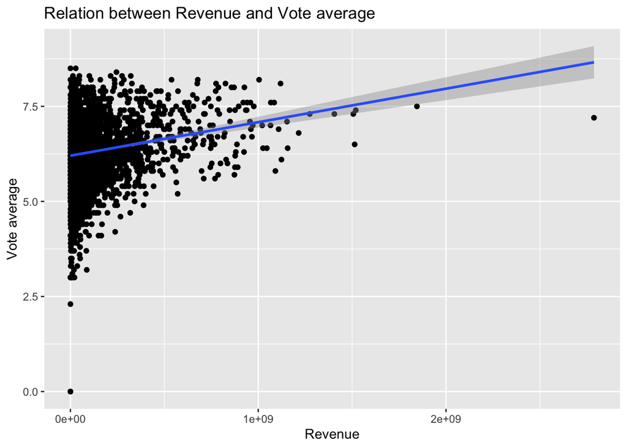

```r
movies_r <- movies_related_revenue %>% select(revenue, budget, vote_average)
cor(movies_r$revenue, movies_r$vote_average)
cor(movies_r$budget, movies_r$vote_average)

ggplot(movies_related_revenue, aes(x=revenue, y=vote_average))+
  geom_point()+
  geom_smooth(method=lm)+
  labs(x="Revenue", y="Vote average", title="Relation between Revenue and Vote average")
```

```r
regression_model = lm(formula = revenue ~ vote_average + budget + genres + production_companies + release_date + spoken_languages, data=movies_related_revenue)

summary(regression_model)
```

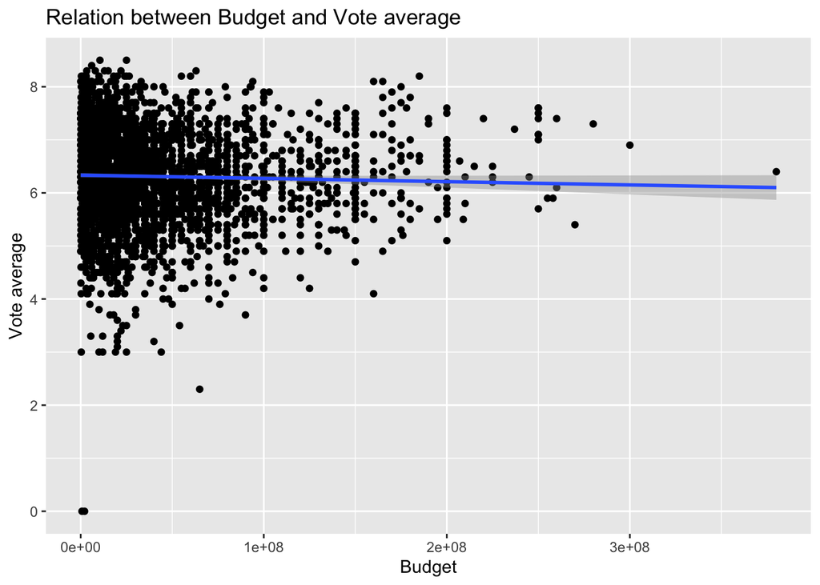

```r
ggplot(movies_related_revenue, aes(x=budget, y=vote_average))+
  geom_point()+
  geom_smooth(method=lm)+
  labs(x="Budget", y="Vote average", title="Relation between Budget and Vote average")
```

```r
regression_model = lm(formula = budget ~ vote_average + revenue + genres + production_companies + release_date + spoken_languages, data=movies_related_revenue)

summary(regression_model)
```

#### Question 4) After that we will see if the duration of film influence the average of users rating.

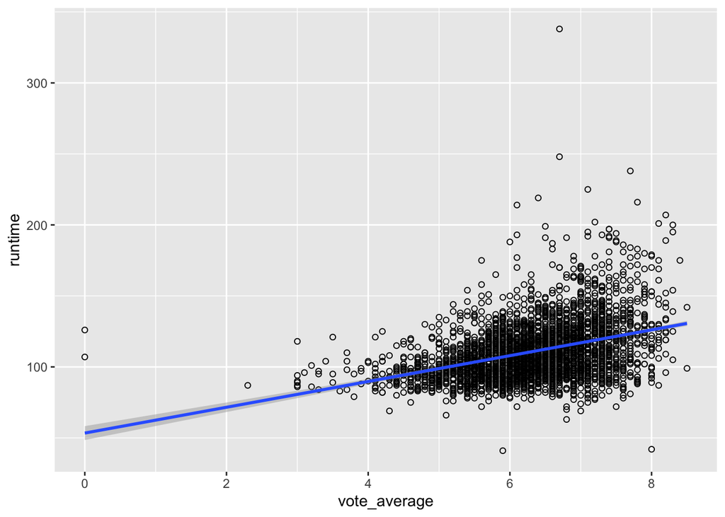

```r
# Numerical value of the correlation
movies_r <- tmdb_movies_clean %>% select(vote_average, runtime)
cor(movies_r$vote_average, movies_r$runtime)

# Graphical representation
ggplot(tmdb_movies_clean, aes(x=vote_average, y=runtime)) +
geom_point(shape=1) +
geom_smooth(method=lm)
```

#### Question 5) The next stage will be analyse the more popular movies genres and how has it changed during years.

```r
# Top3 genres during years
# Select the top genre for each year
popular_genre <- tmdb_movies_clean
popular_genre$year <- format(as.Date(popular_genre$release_date, format="%Y-%m-%d"),"%Y") # add year column

# get first genre
genre <- popular_genre$genres
genre <- as.data.frame(genre)
genre <- separate(genre, col = genre, into = c("1","2","3","4","5","6"))
popular_genre$genres <- genre$`5`
popular_genre <- na.omit(popular_genre) # we have removed an extra film with no genre

popular_genre <- popular_genre %>%
                 select(genres, year)

# Subdivisions years
old_genre <- popular_genre %>%
              filter(year<=1980)
count(old_genre, "genres")
# Top3:
# 1) Drama
# 2) Action and Comedy (equal number of films)

neutral_genre <- popular_genre %>%
              filter(year>1980 && year<2015)
count(neutral_genre, "genres")
# Top3:
# 1) Drama
# 2) Comedy
# 3) Action

new_genre <- popular_genre %>%
              filter(year>=2015)
count(new_genre, "genres")
# Top3:
# 1) Action
# 2) Drama
# 3) Comedy
```

#### Question 6) Moreover we will see if old films have better user scores than recent ones.

```r
# Compare films vote_average of films released on 1980 or before with the ones released on 2015 or after.
tmdb_movies_clean$year <- format(as.Date(tmdb_movies_clean$release_date, format="%Y-%m-%d"),"%Y")

movies_r <- tmdb_movies_clean %>%
            select(vote_average, vote_count, year)

movies_old <- movies_r %>%
              filter(year<=1980)
nrow(movies_old) # number of rows
mean(movies_old$vote_average) # average vote
sum(movies_old$vote_count) # number of votes

movies_now <- movies_r %>%
              filter(year>=2015)
nrow(movies_now) # number of rows
mean(movies_now$vote_average) # average vote
sum(movies_now$vote_count) # number of votes
```

#### Question 7) Lastly we will ask if a film can earn a more than 1 billion dollars if the genre is not one of the most popular gender in that year.

```r
# Filter movies with revenue more than 1.000.000.000 dollars
movies_more_revenue <- tmdb_movies_clean %>%
                       filter(revenue>1000000000)

# Select years from dates of the movies with more revenue
movies_more_revenue$year <- format(as.Date(movies_more_revenue$release_date, format="%Y-%m-%d"),"%Y")

# get first genre
genre <- movies_more_revenue$genres
genre <- as.data.frame(genre)
genre <- separate(genre, col = genre, into = c("1","2","3","4","5","6"))
movies_more_revenue$genres <- genre$`5`
movies_more_revenue <- na.omit(movies_more_revenue) # we have removed an extra film with no genre

movies_more_revenue <- movies_more_revenue %>% select(revenue, year, genres)
movies_more_revenue <- movies_more_revenue[order(movies_more_revenue$year),]
names(movies_more_revenue)[3] <- "movie_genre"

# Select the top genre for each year
year_top_genre <- tmdb_movies_clean
year_top_genre$year <- format(as.Date(year_top_genre$release_date, format="%Y-%m-%d"),"%Y") # add year column

# get first genre
genre <- year_top_genre$genres
genre <- as.data.frame(genre)
genre <- separate(genre, col = genre, into = c("1","2","3","4","5","6"))
year_top_genre$genres <- genre$`5`
year_top_genre <- na.omit(year_top_genre) # we have removed an extra film with no genre

# get genre and year
year_top_genre <- year_top_genre %>% select(genres, year)

year_genre <- year_top_genre %>% select(year, genres) %>%
              group_by(year)

# Compare the genre of each film with the top genre of the release year
join(movies_more_revenue, year_genre, by ="year")
```

#### Question 8) Finally we will see if the release year influences in the popularity and revenue of a movie.

```r
tmdb_movies_clean$year <- as.numeric(format(as.Date(tmdb_movies_clean$release_date, format="%Y-%m-%d"),"%Y"))

# Numerical value of the correlation
movies_r <- tmdb_movies_clean %>% select(year, popularity, revenue)
cor(movies_r$year, movies_r$popularity)
cor(movies_r$year, movies_r$revenue)
```

### Prediction

For the pre-processing stage, we have made some transformations:

- Remove irrelevant variables, such as name (the variable id identifies each entry), keywords and some variables, which format transformation exceeds the scope of this project.
- Convert the name and description attributes, that could be interpreted as categorical variables, to a new field which contains the length of its name/description, in order to find fi this length is relevant for the model.
- Delete missing values for target variables, such as revenue, vote or popularity, in order to train the model correctly. The final data frame looks like this:

```
   budget   ori_lan popularity release_date    revenue   runtime  status   vote_av. vote_count name_l tagline_l
1 237000000   en    150.43758   2009-12-10   2787965087    162   Released    7.2      11800      6       27
2 300000000   en    139.08262   2007-05-19   961000000     169   Released    6.9       4500      40      46
3 245000000   en    107.37679   2015-10-26   880674609     148   Released    6.3       4466      7       21
4 250000000   en    112.31295   2012-07-16   1084939099    165   Released    7.6       9106      21      15
5 260000000   en     43.92699   2012-03-07   284139100     132   Released    6.1       2124      11      36
6 258000000   en    115.69981   2007-05-01   890871626     139   Released    5.9       3576      12      18
```

## Results

### Strength of relationships

#### Question 1)

The variable that have more influency to the *revenue* is the *budget* variable. The one that gets closer to 1 or -1 with the correlation test is the most related. Budget is the higher with 0.7053993.

[output not shown]

#### Question 2)

The variable that influences more to the popularity of the film is the *revenue*. The one that gets closer to 1 or -1 with the correlation test is the most related. Revenue is the higher with 0.602245.

[output not shown]

#### Question 3)

The variable that influences more to get better average mark by users is the *popularity* variable. The one that gets closer to 1 or -1 with the correlation test is the most related. Popularity is the higher with 0.3185934.

| *Budget* | *Revenue* | *Genres* | *Popularity* | *Release_date* | *Spoken_languages* |
| --- | --- | --- | --- | --- | --- |
| -0.03120827 | 0.187839 | 0.028153 | 0.3185934 | 0.0051984 | -0.0018729 |

#### Question 4)

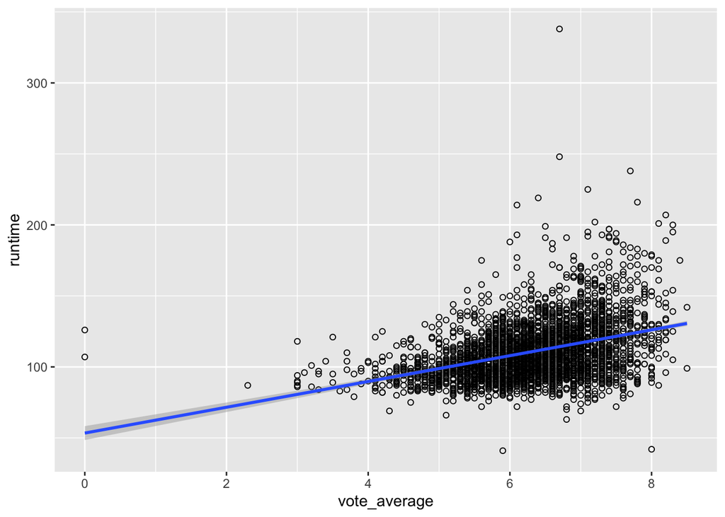

```r
ggplot(tmdb_movies_clean, aes(x=vote_average, y=runtime)) +
geom_point(shape=1) +
geom_smooth(method=lm)
```

#### Question 5)

We split the years in 3 clusters: before 1980, between 1980 and 2014 and after 2015.

- Top3 genres before 1980:
1. Drama
2. Action and Comedy (equal number of films)
- Top3 genres between 1980 and 2014:
1. Drama
2. Comedy
3. Action
- Top3 genres after 2015:
1. Action
2. Drama
3. Comedy

#### Question 6)

|  | *Number of rows* | *Average of votes* | *Number of votes* |
| --- | --- | --- | --- |
| **Old movies (<=1980)** | 219 | 6.93105 | 124385 |
| **recent movies (>=2015)** | 193 | 6.20725 | 321932 |

#### Question 7)

In the results we can see that is difficult that a film can earn more than 1 billion dollars if the genre is not one of the most popular gender in that year.

| *Number films more than $1B* | *Same genre as the popular in that year* | *Different genre than the popular in that year* |
| --- | --- | --- |
| 21 | 18 | 3 |

#### Question 8)

Here we can see that the release year does not influence in the popularity and revenue of a movie as both correlations numbers are close to 0.

| *Popularity* | *Revenue* |
| --- | --- |
| 0.1613506 | 0.1474426 |

### Prediction

We had to compare how well the variable score is predicted by:

- The runtime –> we have had the next output:

```
             actuals predicteds
actuals    1.0000000  0.4146759
predicteds 0.4146759  1.0000000

> regr.eval(actuals_preds$actuals, actuals_preds$predicteds)
      mae       mse      rmse      mape
0.6087162 0.6002294 0.7747448 0.1022778
```

Seeing the correlation index and the rmse, we can conclude that the variables have a similar directional movement. Using the rmse, we can see that the mean error is too low, so the variables are correlated.

- The release date –> we have had the next output:

```
             actuals predicteds
actuals    1.0000000  0.1650971
predicteds 0.1650971  1.0000000

> regr.eval(actuals_preds$actuals, actuals_preds$predicteds)
      mae       mse      rmse      mape
0.6569323 0.7043607 0.8392620 0.1111245
```

In this case, the correlation between the data observed and predicted is two low, so we can’t conclude that both variables are correlated.

## Discussion and Future work

The future work could be divided, mainly, in two main fields:

On one hand, the idea is to explore other possible relations between attributes, for example between the title length and the average vote. Hence, we could find answers to newer questions, like, for example, if the title of the film influences the positive votes or the total views of the film. Even more, we could find the semantic similarities between the words of the title of the most popular films.

On the other hand, the exploration of new algorithms to use, in order to predict with more accuracy, could be a more technical part of the future work. Not only the use of other machine learning techniques but also the employment of deep learning, smarter statistics, etc.